# GSEA_Cutsom_Genes

### 2.3 EDIT: Stappenbeck GSEA via Software

I’m conducting further GSEA using the markers found in the Supplementary Tables 1-4 of the paper. I’ve already formatted the files in excel to only keep the gene marker names.

```r
goblet <- read_excel(here::here("GSEA_software_files", "Stappenbeck_files", "Stappenbeck_markers", "Table_S1_Goblet_Cell.xlsx"), col_names = TRUE)
entero <- read_excel(here::here("GSEA_software_files", "Stappenbeck_files", "Stappenbeck_markers", "Table_S2_Enteroendocrine_Cell.xlsx"), col_names = TRUE)
DSS <- read_excel(here::here("GSEA_software_files", "Stappenbeck_files", "Stappenbeck_markers", "Table_S3_DSS-Associated_Regenerative.xlsx"), col_names = TRUE)
fetal <- read_excel(here::here("GSEA_software_files", "Stappenbeck_files", "Stappenbeck_markers", "Table_S4_Fetal_Epithelial.xlsx"), col_names = TRUE)

stappenbeck_stables_markers <- list(goblet, entero, DSS, fetal)
names(stappenbeck_stables_markers) <- c("goblet", "entero", "DSS", "fetal")

stappenbeck_stables_markers <- map(stappenbeck_stables_markers, ~ .x %>%
                                     left_join(mm_to_HGNC, by = c("PROBE" = "mouse")))

not_in_stap <- map(stappenbeck_stables_markers, ~ .x %>%
                     filter(is.na(human)))

head(not_in_stap)
```

```
## $goblet
## # A tibble: 36 x 3
##    PROBE   Homologue_number human
##    <chr>              <dbl> <chr>
##  1 Ces1c             117484 <NA>
##  2 Ang4              135633 <NA>
##  3 Ccl6               22507 <NA>
##  4 Ces1e             115660 <NA>
##  5 Cyp2c68            74936 <NA>
##  6 Gstm3              37356 <NA>
##  7 Igtp               23118 <NA>
##  8 Adh6a              66291 <NA>
##  9 Cyp2d26           130660 <NA>
## 10 Gm15564               NA <NA>
## # ... with 26 more rows
##
## $entero
## # A tibble: 32 x 3
##    PROBE         Homologue_number human
##    <chr>                    <dbl> <chr>
##  1 Ces1c                   117484 <NA>
##  2 1700086L19Rik               NA <NA>
##  3 Ang4                    135633 <NA>
##  4 Ccl6                     22507 <NA>
##  5 Ccl9                     86734 <NA>
##  6 Fam183b                  28543 <NA>
##  7 Rap1gapos                   NA <NA>
##  8 Gm11963                     NA <NA>
##  9 Nefm                    137211 <NA>
## 10 1810041L15Rik               NA <NA>
## # ... with 22 more rows
##
## $DSS
## # A tibble: 43 x 3
##    PROBE    Homologue_number human
##    <chr>               <dbl> <chr>
##  1 Ctgf                   NA <NA>
##  2 Tnfsf9             137221 <NA>
##  3 Abi3bp             134172 <NA>
##  4 mt-Tc                  NA <NA>
```

[output cut: 8 more lines]

```
## $fetal
## # A tibble: 30 x 3
##    PROBE         Homologue_number human
##    <chr>                    <dbl> <chr>
##  1 Ctgf                        NA <NA>
##  2 Prl2c3                   40763 <NA>
##  3 Serpinb9b               137240 <NA>
##  4 Fam198b                     NA <NA>
##  5 Ggta1                     7730 <NA>
##  6 Crip2                   133917 <NA>
##  7 Serpinb6b                22633 <NA>
##  8 Prkcdbp                     NA <NA>
##  9 1110028F11Rik               NA <NA>
## 10 Oas1f                    86720 <NA>
## # ... with 20 more rows
```

Okay, looking at a few of the mouse genes, they don’t seem to have a human homologue. I’m just going to take those ones out.

```r
stappenbeck_stables_markers <- map(stappenbeck_stables_markers, ~ .x %>%
                                     na.omit(x))

stappenbeck_stables_markers <- map(stappenbeck_stables_markers, ~ .x %>%
                                     dplyr::select(human))

#write.xlsx(stappenbeck_stables_markers, file = here::here("GSEA_software_files", "Stappenbeck_files", "Stappenbeck_markers", "stappenbeck_markers_tables_s1_s4.xlsx"), col.names = FALSE)
```

**EDIT:** I’m going to load the detailed GSEA results tables output from the GSEA software to make the NES plots.

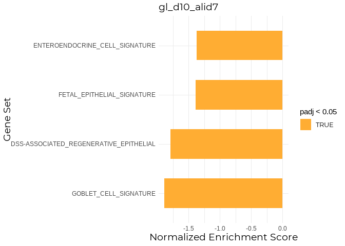

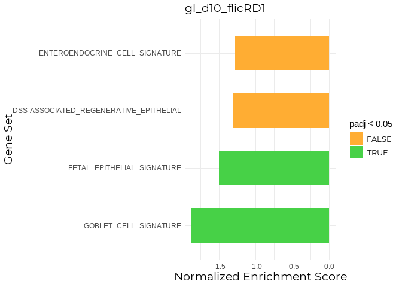

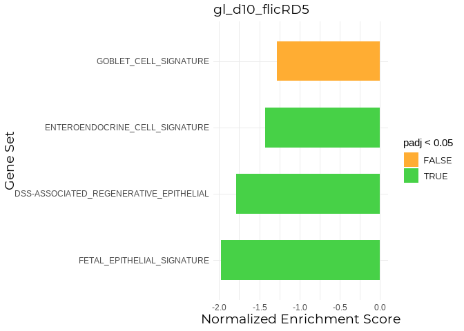

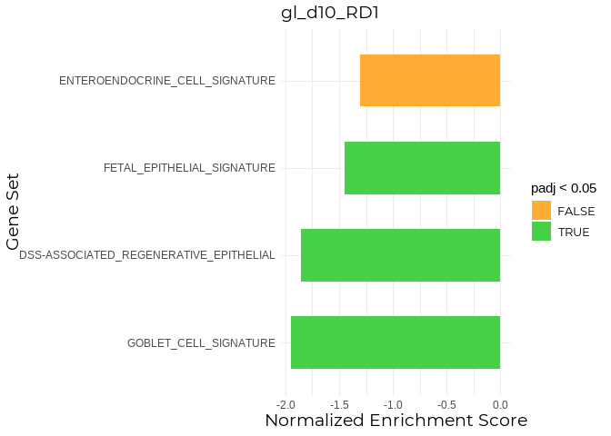

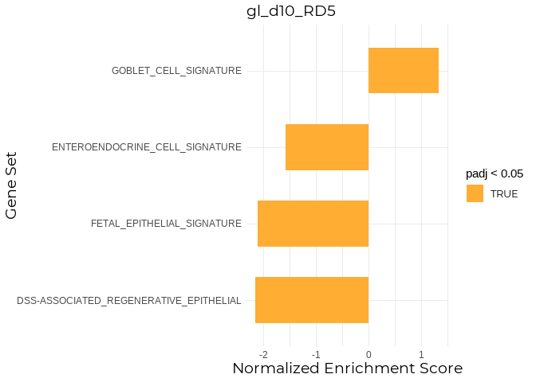

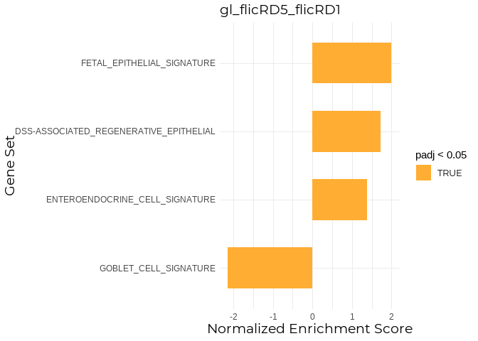

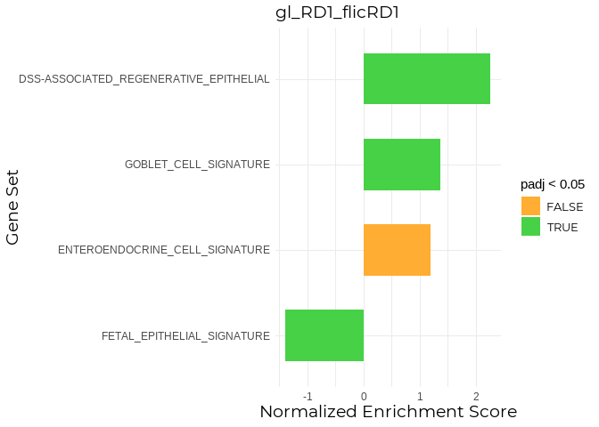

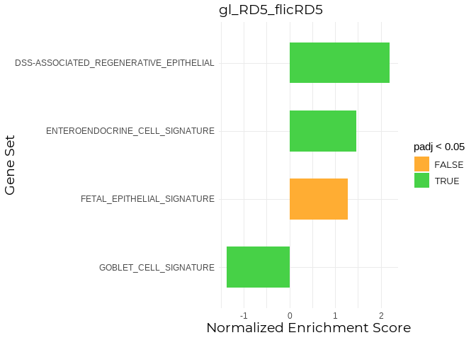

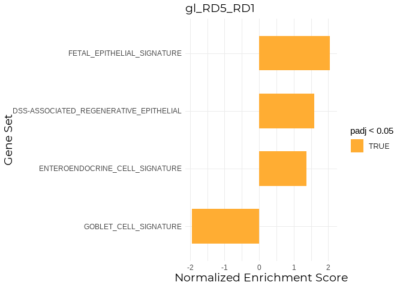

```r
#when using this function, check which your working directory is and your Knitr directory.
Stappenbeck_GSEA_results <- list.files(pattern = "_GSEA_results.xlsx$", recursive = TRUE, full.names = TRUE) %>%
  set_names(nm = (basename(.) %>%
                    tools::file_path_sans_ext())) %>%
  map(read_excel)

names(Stappenbeck_GSEA_results) <- names(all_gl)
#write.xlsx(Stappenbeck_GSEA_results, file = here::here("data", "Processed", "ibd_fgsea_stappenbeck_TableS1-S4_results.xlsx"), colnames = TRUE)

#renaming to padj cause original is named FDR q val
Stappenbeck_GSEA_results <- lapply(Stappenbeck_GSEA_results, function (x) {colnames(x)[6] <- "padj"; x})

stappenbeck_NES_plots <- list()

for (i in seq_along(Stappenbeck_GSEA_results)){
  x <- ggplot(Stappenbeck_GSEA_results[[i]], aes(x = reorder(NAME, NES), y = NES)) +
    geom_col(aes(fill = padj < 0.05, width = 0.6)) +
    scale_fill_manual(values = c("#ffad33", "#47d147")) +
    coord_flip() +
    labs(x = "Gene Set", y = "Normalized Enrichment Score") +
    ggtitle(names(Stappenbeck_GSEA_results[i])) +
    my_theme
  stappenbeck_NES_plots[[i]] <- x
}

names(stappenbeck_NES_plots) <- names(all_gl)

stappenbeck_NES_plots
```

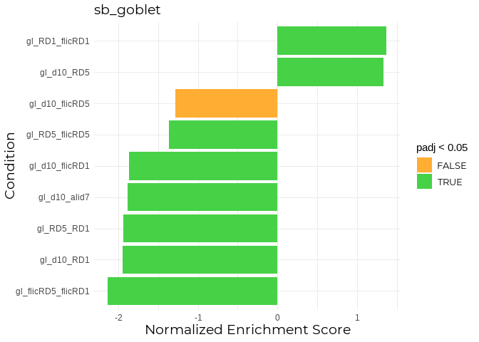

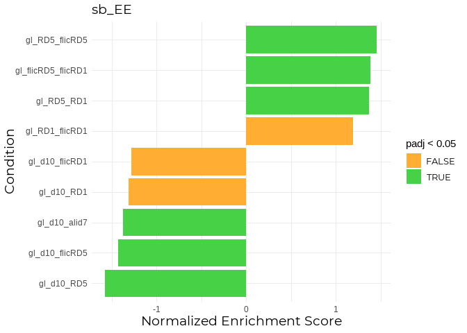

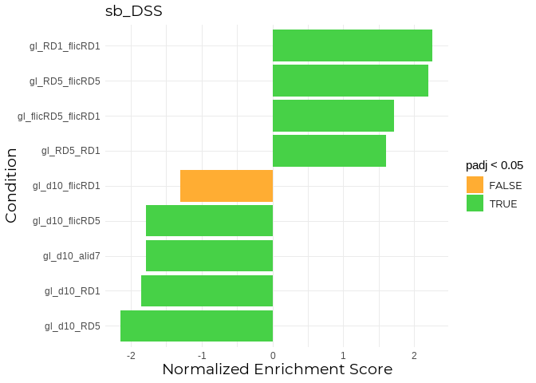

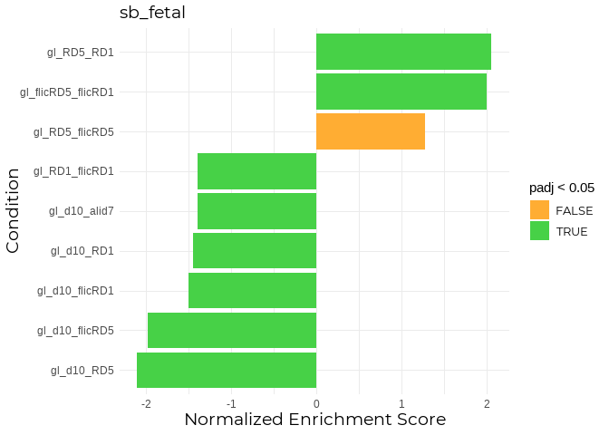

```r
#Rearranging to include readings for each geneset in one list, rather than dividing by genelist
sb_goblet <- map(Stappenbeck_GSEA_results, function(x) x %>%
                   filter(NAME == "GOBLET_CELL_SIGNATURE"))
sb_goblet <- do.call(rbind, sb_goblet)

sb_EE <- map(Stappenbeck_GSEA_results, function(x) x %>%
                   filter(NAME == "ENTEROENDOCRINE_CELL_SIGNATURE"))
sb_EE <- do.call(rbind, sb_EE)

sb_DSS <- map(Stappenbeck_GSEA_results, function(x) x %>%
                   filter(NAME == "DSS-ASSOCIATED_REGENERATIVE_EPITHELIAL"))
sb_DSS <- do.call(rbind, sb_DSS)

sb_fetal <- map(Stappenbeck_GSEA_results, function(x) x %>%
                   filter(NAME == "FETAL_EPITHELIAL_SIGNATURE"))
sb_fetal <- do.call(rbind, sb_fetal)

sb_list <- list(sb_goblet, sb_EE, sb_DSS, sb_fetal)
names(sb_list) <- c("sb_goblet", "sb_EE", "sb_DSS", "sb_fetal")

sb_list <- map(sb_list, function(x) x %>%
                 rownames_to_column(var = "comparison"))

stappenbeck_NES_plots_2 <- list()

for (i in seq_along(sb_list)){
  x <- ggplot(sb_list[[i]], aes(x = reorder(comparison, NES), y = NES)) +
    geom_col(aes(fill = padj < 0.05)) +
    scale_fill_manual(values = c("#ffad33", "#47d147")) +
    coord_flip() +
    labs(x = "Condition", y = "Normalized Enrichment Score") +
    ggtitle(names(sb_list[i])) +
    my_theme
  stappenbeck_NES_plots_2[[i]] <- x
}

names(stappenbeck_NES_plots_2) <- names(sb_list)

stappenbeck_NES_plots_2
```

## 3.0 Smillie et. al., Markers

Let’s now take a look at the markers from [this paper by Smillie, C et al.,](https://www.sciencedirect.com/science/article/pii/S0092867419307329?via%3Dihub).

I already appended the Excel file to put each gene into a separate cell. I’ll now make it into a df so that all genes are in one column.

```r
#Smillie markers
smillie <- read_excel(here::here("data", "Processed", "Smillie_genes.xlsx"), col_names = TRUE)

smillie
```

```
## # A tibble: 71 x 16
##    `UC GSEA Genes` Overlap ...3  ...4  ...5  ...6  ...7  ...8  ...9  ...10 ...11
##    <chr>           <chr>   <chr> <chr> <chr> <chr> <chr> <chr> <chr> <chr> <chr>
##  1 E_epithelial    TNFRSF~ IFNG~ TNFS~ SMPD1 SPAT~ HIST~ PARP4 CHMP~ TICA~ <NA>
##  2 E_epithelial    EZR     CGN   TJP3  ARHG~ MYH14 MARV~ SLC9~ SYNPO ARHG~ SRC
##  3 E_epithelial    PIP5K1B PDGFA SLC9~ SCIN  BDKR~ MAPK3 GNG12 <NA>  <NA>  <NA>
##  4 E_epithelial    GBA     CTSD  IDS   LITAF ARSA  CTSA  <NA>  <NA>  <NA>  <NA>
##  5 E_epithelial    EHD1    VPS3~ IL2RG SMAD3 PDCD~ DNM2  <NA>  <NA>  <NA>  <NA>
##  6 E_epithelial    CASP7   CASP~ <NA>  <NA>  <NA>  <NA>  <NA>  <NA>  <NA>  <NA>
##  7 E_epithelial    PTK2B   DGKA  PPAP~ <NA>  <NA>  <NA>  <NA>  <NA>  <NA>  <NA>
##  8 E_epithelial    CDKN1A  JUND  GNA11 AKAP~ <NA>  <NA>  <NA>  <NA>  <NA>  <NA>
##  9 E_epithelial    IL22RA1 IFNL~ PIM1  <NA>  <NA>  <NA>  <NA>  <NA>  <NA>  <NA>
## 10 E_epithelial    WIPF2   PSD4  RAB1~ WASL  ITCH  ACAP2 CDC42 EPN1  CHMP~ CHMP~
## # ... with 61 more rows, and 5 more variables: ...12 <chr>, ...13 <chr>,
## #   ...14 <chr>, ...15 <chr>, Condition <chr>
```

```r
smillie <- smillie %>%
  pivot_longer(names_to = "x", values_to = "gene", cols = 2:15)

smillie
```

```
## # A tibble: 994 x 4
##    `UC GSEA Genes` Condition x       gene
##    <chr>           <chr>     <chr>   <chr>
##  1 E_epithelial    UC        Overlap TNFRSF1A
##  2 E_epithelial    UC        ...3    IFNGR2
##  3 E_epithelial    UC        ...4    TNFSF10
##  4 E_epithelial    UC        ...5    SMPD1
##  5 E_epithelial    UC        ...6    SPATA2L
##  6 E_epithelial    UC        ...7    HIST1H2AC
##  7 E_epithelial    UC        ...8    PARP4
##  8 E_epithelial    UC        ...9    CHMP1A
##  9 E_epithelial    UC        ...10   TICAM1
## 10 E_epithelial    UC        ...11   <NA>
## # ... with 984 more rows
```

```r
smillie <- smillie [-c(3)]

smillie <- na.omit(smillie)

dim(smillie)
```

```
## [1] 292   3
```

Adding matching entrez genes:

```r
colnames(smillie) [1] <- "cell_type"

#adding entrez
smillie <- smillie %>%
  left_join(HGNC_to_Entrez, by = c("gene" = "human_gene_symbol"))

smillie_na <- smillie %>%
  filter(is.na(human_entrez_gene))

smillie_na
```

```
## # A tibble: 6 x 4
##   cell_type    Condition gene      human_entrez_gene
##   <chr>        <chr>     <chr>                 <dbl>
## 1 E_epithelial UC        HIST1H2AC                NA
## 2 E_epithelial UC        PPAP2A                   NA
## 3 E_epithelial UC        C1orf106                 NA
## 4 E_epithelial UC        C9orf41                  NA
## 5 E_epithelial Control   PPAP2A                   NA
## 6 E_epithelial Control   ERBB2IP                  NA
```

There’s a few NAs. [Genecards](https://www.genecards.org) shows that these genes actually do exist, but that they’re known by their more popular names. I’m going to manually add the names of these genes.

```r
gene_name_aliases <- as.data.frame(smillie_na$gene)

gene_name_aliases$alternative_name <- c("H2AC6", "PLPP1", "INAVA", "CARNMT1", "PLPP1", "ERBIN")

gene_name_aliases
```

```
##   smillie_na$gene alternative_name
## 1       HIST1H2AC            H2AC6
## 2          PPAP2A            PLPP1
## 3        C1orf106            INAVA
## 4         C9orf41          CARNMT1
## 5          PPAP2A            PLPP1
## 6         ERBB2IP            ERBIN
```

```r
#joining to smillie_na
smillie_na <- smillie_na %>%
  right_join(gene_name_aliases, by = c("gene" = "smillie_na$gene"))

smillie_na
```

```
## # A tibble: 8 x 5
##   cell_type    Condition gene      human_entrez_gene alternative_name
##   <chr>        <chr>     <chr>                 <dbl> <chr>
## 1 E_epithelial UC        HIST1H2AC                NA H2AC6
## 2 E_epithelial UC        PPAP2A                   NA PLPP1
## 3 E_epithelial UC        PPAP2A                   NA PLPP1
## 4 E_epithelial UC        C1orf106                 NA INAVA
## 5 E_epithelial UC        C9orf41                  NA CARNMT1
## 6 E_epithelial Control   PPAP2A                   NA PLPP1
## 7 E_epithelial Control   PPAP2A                   NA PLPP1
## 8 E_epithelial Control   ERBB2IP                  NA ERBIN
```

```r
#removing duplicaate rows
smillie_na <- smillie_na %>%
  distinct()

#removing original gene names
smillie_na <- smillie_na %>%
  select(cell_type, Condition, alternative_name)

colnames(smillie_na)[3] <- "gene"

#adding entrez genes
smillie_na <- smillie_na %>%
  left_join(HGNC_to_Entrez, by = c("gene" = "human_gene_symbol"))

smillie_na
```

```
## # A tibble: 6 x 4
##   cell_type    Condition gene    human_entrez_gene
##   <chr>        <chr>     <chr>               <dbl>
## 1 E_epithelial UC        H2AC6                8334
## 2 E_epithelial UC        PLPP1                8611
## 3 E_epithelial UC        INAVA               55765
## 4 E_epithelial UC        CARNMT1            138199
## 5 E_epithelial Control   PLPP1                8611
## 6 E_epithelial Control   ERBIN               55914
```

```r
smillie_na <- smillie_na %>%
  distinct()

smillie_na
```

```
## # A tibble: 6 x 4
##   cell_type    Condition gene    human_entrez_gene
##   <chr>        <chr>     <chr>               <dbl>
## 1 E_epithelial UC        H2AC6                8334
## 2 E_epithelial UC        PLPP1                8611
## 3 E_epithelial UC        INAVA               55765
## 4 E_epithelial UC        CARNMT1            138199
## 5 E_epithelial Control   PLPP1                8611
## 6 E_epithelial Control   ERBIN               55914
```

```r
nrow(smillie) #292
```

```
## [1] 292
```

```r
nrow(smillie_na) #6
```

```
## [1] 6
```

```r
292 - 6
```

```
## [1] 286
```

```r
smillie <- na.omit(smillie)

nrow(smillie) #286 = deleted 6 entries
```

```
## [1] 286
```

```r
smillie <- rbind(smillie, smillie_na)

which(is.na(smillie)) #perfect, done
```

```
## integer(0)
```

```r
#renaming entrez column to gene

colnames(smillie) [3:4] <- c("gene_symbol", "gene")
```

I’ll now separate the dataframe by the cell-type and by condition, so 2 dfs per cell type: ulcerative colities and control

```r
smillie %>%
  count(cell_type, Condition)
```

```
## # A tibble: 4 x 3
##   cell_type       Condition     n
##   <chr>           <chr>     <int>
## 1 E_epithelial    Control      95
## 2 E_epithelial    UC          129
## 3 immature_goblet Control      34
## 4 immature_goblet UC           34
```

```r
epithelial_control <- smillie %>%
  dplyr::filter (cell_type == "E_epithelial" & Condition == "Control") %>%
  mutate(term = "SMILLIE_EPITHELIAL_Control") %>%
  dplyr::select(term, gene)
dim(epithelial_control) #95
```

```
## [1] 95  2
```

```r
epithelial_uc <- smillie %>%
  dplyr::filter (cell_type == "E_epithelial" & Condition == "UC") %>%
  mutate(term = "SMILLIE_EPITHELIAL_UC") %>%
  dplyr::select(term, gene)
dim(epithelial_uc) #129
```

```
## [1] 129   2
```

```r
goblet_control <- smillie %>%
  dplyr::filter (cell_type == "immature_goblet" & Condition == "Control")  %>%
  mutate(term = "SMILLIE_IMMATURE_GOBLET_Control") %>%
  dplyr::select(term, gene)
dim(goblet_control) #34
```

```
## [1] 34  2
```

```r
goblet_uc <- smillie %>%
  dplyr::filter (cell_type == "immature_goblet" & Condition == "UC") %>%
  mutate(term = "SMILLIE_IMMATURE_GOBLET_UC") %>%
  dplyr::select(term, gene)
dim(goblet_uc) #34
```

```
## [1] 34  2
```